# Supervised Learning - Foundations Project: ReCell

# Exploratory Data Analysis

- It is a good idea to explore the data once again after manipulating it.

```python
df1.describe().T
df1.info()
```

```
<class 'pandas.core.frame.DataFrame'>
RangeIndex: 3454 entries, 0 to 3453
Data columns (total 15 columns):
 #   Column                 Non-Null Count  Dtype
---  ------                 --------------  -----
 0   brand_name             3454 non-null   object
 1   os                     3454 non-null   object
 2   screen_size            3454 non-null   float64
 3   4g                     3454 non-null   object
 4   5g                     3454 non-null   object
 5   main_camera_mp         3454 non-null   float64
 6   selfie_camera_mp       3454 non-null   float64
 7   int_memory             3454 non-null   float64
 8   ram                    3454 non-null   float64
 9   battery                3454 non-null   float64
 10  weight                 3454 non-null   float64
 11  release_year           3454 non-null   int64
 12  days_used              3454 non-null   int64
 13  normalized_used_price  3454 non-null   float64
 14  normalized_new_price   3454 non-null   float64
dtypes: float64(9), int64(2), object(4)
memory usage: 404.9+ KB
```

### Observations from `df1.describe().T` and `df1.info()`

- **No missing values** remain in the dataset — all 3,454 rows are complete across all 15 columns.
- **Numerical features (11 total)**: include variables like `screen_size`, `battery`, `ram`, and both normalized price fields. These are mostly of type `float64`, with two (`release_year`, `days_used`) as `int64`.
- **Categorical features (4 total)**: include `brand_name`, `os`, `4g`, and `5g`. These will need to be encoded before modeling.
- **Memory usage is light** at ~405 KB, indicating efficient data storage.
- The dataset is now clean and ready for further analysis, feature engineering, and modeling.

### Distribution Plots for Numeric Features

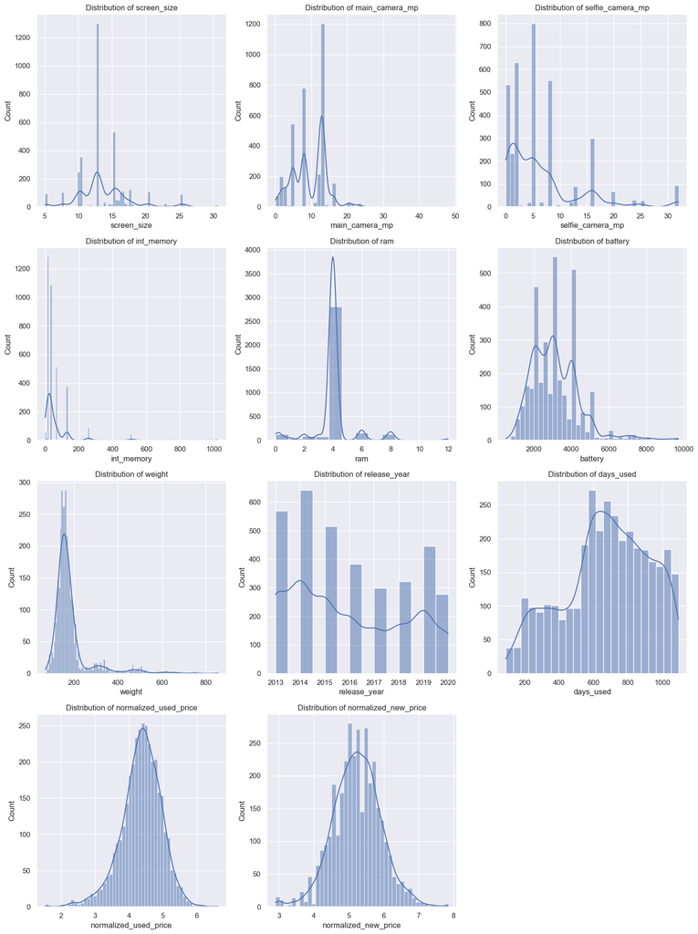

```python
##Check for skewness, modality, and distribution shape.

import matplotlib.pyplot as plt
import seaborn as sns

num_cols = df1.select_dtypes(include="number").columns.tolist()

plt.figure(figsize=(15, 20))
for i, col in enumerate(num_cols):
    plt.subplot(len(num_cols) // 3 + 1, 3, i + 1)
    sns.histplot(df1[col], kde=True)
    plt.title(f'Distribution of {col}')
plt.tight_layout()
plt.show()
```